# Determining the Utility of TMPRSS2-ERG Fusion Status for Prediction of Disease Aggressiveness

Author

Evan Saitsky

# Overview

Prostate cancer is the second most common type of cancer in the United States, with an estimated 300,000 new cases in 2024. Despite recent innovations (e.g., radioligand therapeutics, PMSA Imaging), there remains distinct patient-segments with high unmet need due to unique tumor characteristics. Disease aggressiveness, a term that is often ambiguously defined and inconsistently treated in real-world setting, refers to an aggregate blend of patient features that includes prognostic markers (Gleason Score), altered genetic markers (P53, RB, MYC), rapid disease progression, and presence of visceral metastases (cancer that has spread to organs). Within this analysis my goal is to create a clinically actionable definition of ‘aggressive disease’ by integrating prognostic variables to form a compositive score. I will then evaluate whether we can use the presence of a genetic mutation to predict whether a patient will classify as having aggressive disease.

# Introduction

The prostate cancer diagnostic and treatment armamentarium is variable and at times highly complex due evolving US diagnostic guidelines and distinctive treatment patterns amongst HCPs (urologist vs. medical oncologist). Prostate-specific antigen (PSA) testing is a blood test that helps to detect likelihood of disease via rising PSA levels. Despite broad adoption, the effectiveness of PSA as a screening modality is debated, with multiple guidelines changes in recent decades.

- Prior to 2008, PSA testing was recommended for all men >50.
- However, studies demonstrated that ~50 men had to be treated to save one life. The burden of treatment was seen as unnecessarily high, leading to discontinuation of routine testing.
- With less PSA testing the diagnosis rate of metastatic disease increased. This resulted in a re-evaluation in 2017, with present literature suggesting that men with risk factors such as BRCA mutated, specific minority status, or immediate family histories discuss screening at age 40 – 45.

The Gleason Score (GS) is a pathological grading system used to determine prognosis and to help inform optimal treatment approach. The higher the Gleason Score, the more abnormal the tissue and more likely the cancer will grow quickly. GS is also used in conjunction with clinical stage, serum PSA, and tumor volume to help determine treatment for newly diagnosed patients.

- The GS score is calculated by rating differentiation amongst the 2 most prevalent tumor patterns on a 1-5 scale, and then summing to find a total composite score out of 10. A GS of 2 – 6 is considered low risk, 7 is considered intermediate risk, and 8 – 10 is considered high risk.

This brings us back to the phrase aggressive disease. Not only do patients with aggressive disease have meaningfully worse health outcomes, but approach to treatment is reliant on early identification and HCP treatment sequencing decisions in prior lines of therapy. Lack of a standard definition further confounds this challenge (e.g., The LATTITUDE and CHAARTED trials used different criteria to define high-risk disease). To address this challenge and improve patient outcomes we must develop a more cohesive definition for aggressive disease and identify clinical variables that can predict aggressiveness. In this analysis I will examine the significance of TMRPSS2-ERG fusion status and determine whether there is predictive capability for disease aggressiveness.

# R Packages

The following packages were read into this project to support data standardization and analysis.

```r
library(tidyverse)
library("naniar")
library("mice")
library("factoextra")
library(magrittr)
library(dplyr)
library(caret)
library(randomForest)
library(glmnet)
library("table1")
```

# Methodology

The dataset that I utilized in this project is from the cBioPortal for Cancer Genomics. The cBioPortal is a well-established open-source platform that allows researchers to engage in interactive exploration of cancer genomics data sets (data is curated from >=350 studies). The data of interest, Prostate Adenocarcinoma (Broad/Cornell, Nat Genet 2012), was generated by Levi Garraway’s lab at the Broad Institute and Mark Rubin’s lab at Cornell. I was able to evaluate and perform supervised machine learning analyses on the N=123 unique patient samples due to presence of a case/control, which took the form of TMPRSS2-ERG Fusion Status – with ~50% of the patients positive, ~50% negative. To initiate the analysis I had to import the dataset from the cBioPortal. I loaded library(“table1”) to help create formatted summary tables for the clinical data, which was obtained from cBioPortal in TSV format. From there I used name_repair = “universal_quiet” for naming standardization and syntax alignment. Lastly, I used the rename function to change the name of some of the lengthier column names to make it easier to analyze the data.

There are n=123 rows read in, which represents N=123 unique patient samples from the cBioPortal data.

```r
Clinical=read_tsv("prad_broad_clinical_data (2).tsv", name_repair = "universal_quiet")
Clinical = Clinical |>
  rename(Age = Diagnosis.Age,
         FGA.Status = Fraction.Genome.Altered,
         Prostatectomy.Gleason.Score = Radical.Prostatectomy.Gleason.Score.for.Prostate.Cancer,
         Capra.Score = Modified.Capra.S.Score.Without.Including.Surgical.Margins,
         PSA.Status = Serum.PSA,
         Tumor.Mutation.Burden = TMB..nonsynonymous.)
```

## Assessed Missingness

My next The functionvis_miss was used to determine that the dataset had several missing values.

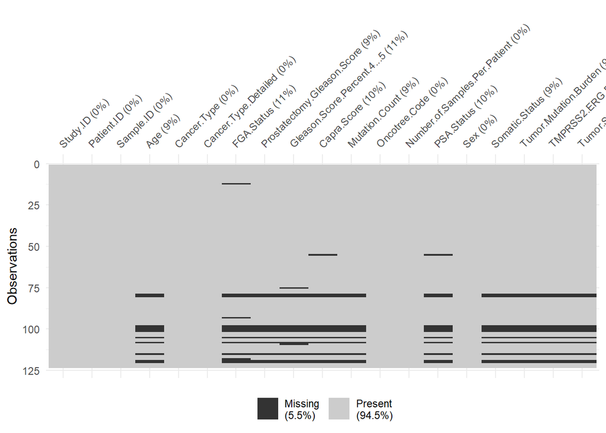

```r
## Assess Missingness
vis_miss(Clinical)
```

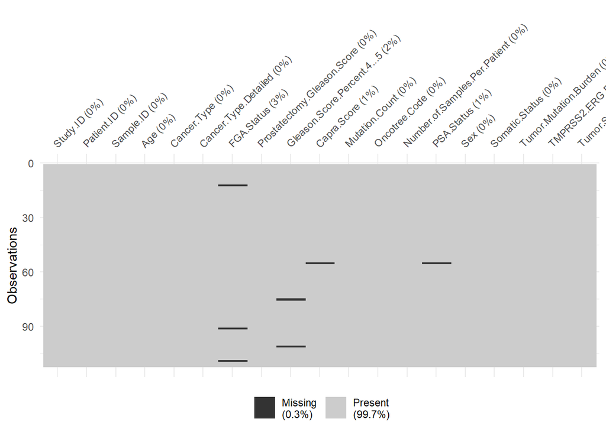

```r
Clinical = Clinical |>
  drop_na(Age)

vis_miss(Clinical)
```

```r
## Going to impute FGA where we have some missingness
## Installed MICE Library

Clinical.mids = mice(Clinical)
Clinical = complete(Clinical.mids) ## Gives clinical dataframe with 112 obs & 0 missing
```

## Outlier Removal, New Column

```r
## Exclude N=1 TMB outlier
Clinical = Clinical |>
  filter(Tumor.Mutation.Burden<=3) |>
  mutate(Log.FGA.Status=log(FGA.Status))
## New FGA Column with Imputed Columns
```

## Simplified Representation of TMPRSS2.ERG.Fusion.Status

- TMPRSS2.ERG.Fusion.Status is represented three ways within the dataset sourced from cBioPortal
  - Negative
  - Positive
  - Positive with interstitial deletion
- For simplicity purposes in the upfront analysis I changed TMPRSS2.ERG.Fusion.Status to positive or negative, effectively folding the positive with interstitial deletion into the positive cohort.
- This allows us to nearly have a 50/50 split between patients with a negative vs. positive mutation status.
  - In subsequent analyses I brought back the three distinct groups for more nuanced insights and preferred predictors.

```r
table(Clinical$TMPRSS2.ERG.Fusion.Status)
```

```
                           Negative                            Positive
                                 53                                  24
Positive with interstitial deletion
                                 34
```

```r
Clinical=Clinical |>
  mutate(TMPRSS2.Simplified=factor(if_else(TMPRSS2.ERG.Fusion.Status=="Positive with interstitial deletion",
                                           "Positive", TMPRSS2.ERG.Fusion.Status),
                                   levels = c('Negative', 'Positive')),
         Interstitial.Deletion = factor(if_else(TMPRSS2.ERG.Fusion.Status=="Positive with interstitial deletion",
                                                "Yes", "No"),
                                        levels = c('No', 'Yes')),
         TMPRSS2.Full = factor(if_else(TMPRSS2.ERG.Fusion.Status=="Positive",
                                       "Positive, no interstitial deletion", TMPRSS2.ERG.Fusion.Status),
                               levels = c('Negative',
                                          'Positive, no interstitial deletion',
                                          'Positive with interstitial deletion')))
```

## Aggregated Radical Prostatectomy Gleason

- Combined the inputs from Radical Prostatectomy Gleason Score for Prostate Cancer
  - This combined the two separate numerics and made a single composite score that was easier to compute (e.g., 3 + 4 = 7)
  - The numerics are referred to as the primary and secondary cancer cell pattern scores
    - Primary grade: The grade of the largest area of the tumor
    - Secondary grade: The grade of the second largest area of the tumor

```r
Clinical = Clinical |>
  mutate(Tumor.Stage.Binary=str_sub(Tumor.Stage,1,3)) |>
  rowwise() |>
  mutate(Composite.Gleason.Score = eval(parse(text=Prostatectomy.Gleason.Score))) |>
  ungroup()
```

## Patient Demographics: Initial Data Visualization and Exploratory Analysis

- Demographic overview from available data e.g., age, tumor stage, mutation counts, mutation status, and Capra Score

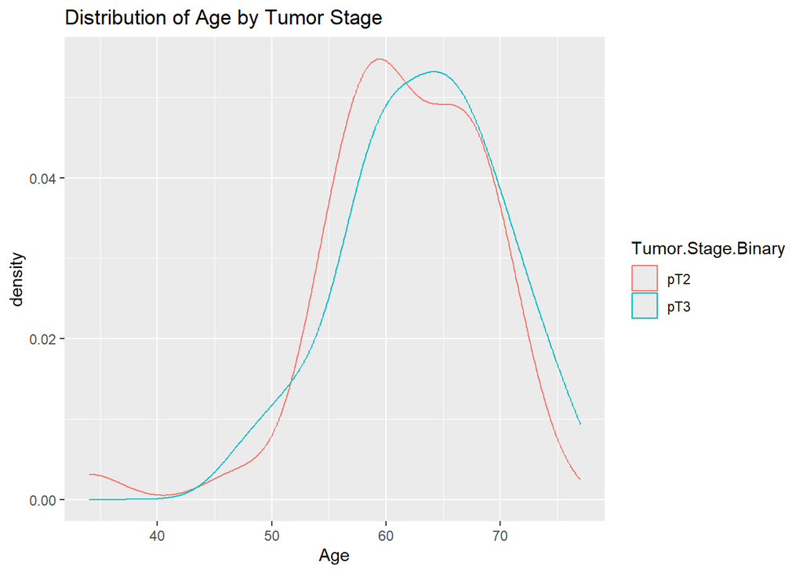

```r
## Density Curve
ggplot(Clinical,aes(x=Age, color=Tumor.Stage.Binary)) +
  geom_density() +
  labs(title="Distribution of Age by Tumor Stage")
```

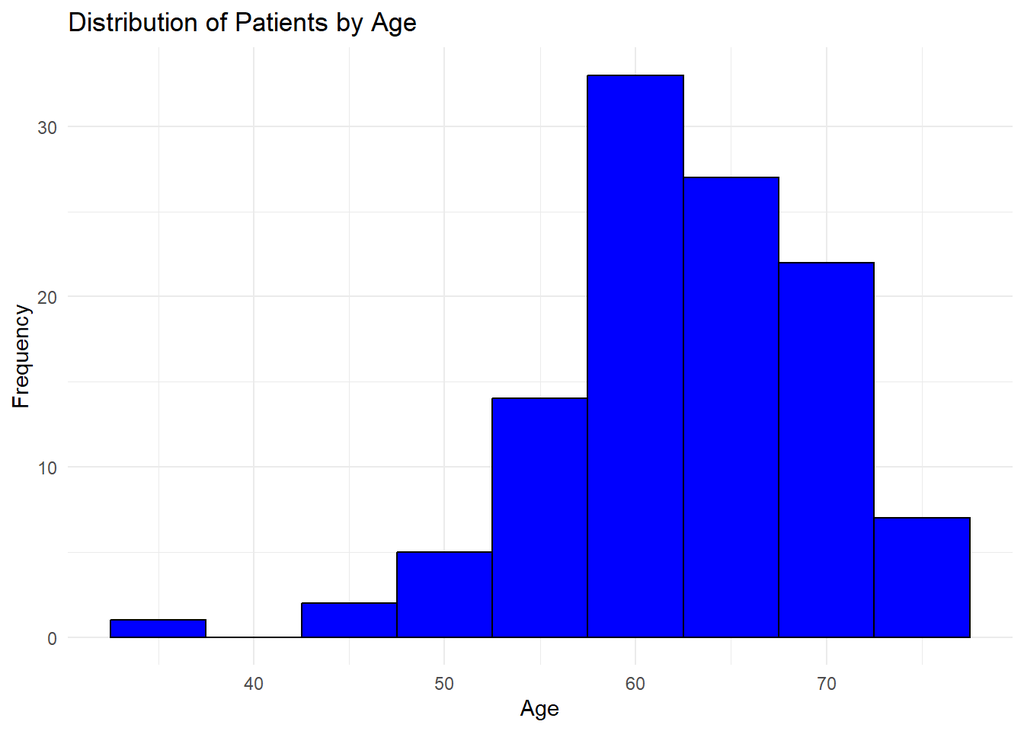

```r
##Distribution of patients by age
ggplot(Clinical, aes(x = Age)) +
  geom_histogram(binwidth = 5, fill = "blue", color = "black") +
  labs(title = "Distribution of Patients by Age", x = "Age", y = "Frequency") +
  theme_minimal()
```

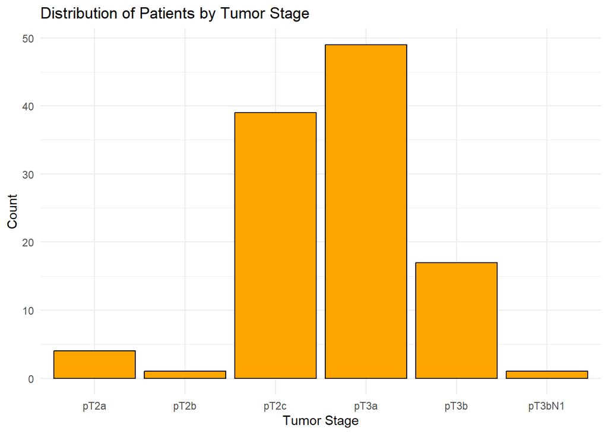

```r
## Distribution of patients by tumor stage
ggplot(Clinical, aes(x = Tumor.Stage)) +
  geom_bar(fill = "orange", color = "black") +
  labs(title = "Distribution of Patients by Tumor Stage", x = "Tumor Stage", y = "Count") +
  theme_minimal()
```

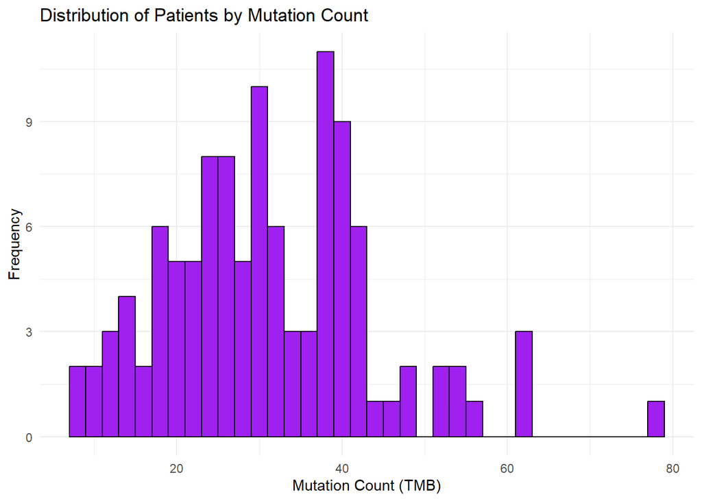

```r
## Distribution of patients by mutation count
ggplot(Clinical, aes(x = Mutation.Count)) +
  geom_histogram(binwidth = 2, fill = "purple", color = "black") +
  labs(title = "Distribution of Patients by Mutation Count", x = "Mutation Count (TMB)", y = "Frequency") +
  theme_minimal()
```

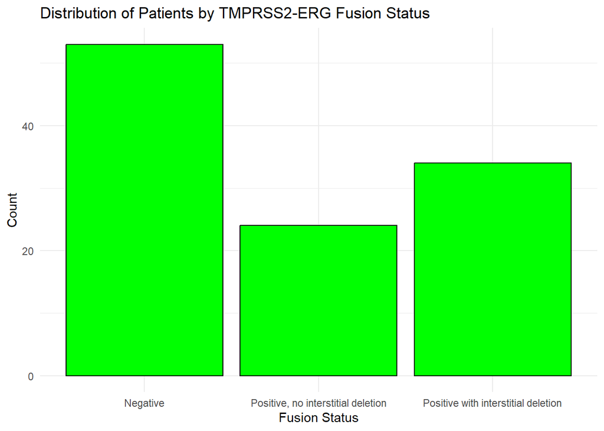

```r
# 4. Distribution of patients with TMPRSS2-ERG fusion status
ggplot(Clinical, aes(x = TMPRSS2.Full)) +
  geom_bar(fill = "green", color = "black") +
  labs(title = "Distribution of Patients by TMPRSS2-ERG Fusion Status", x = "Fusion Status", y = "Count") +
  theme_minimal()
```

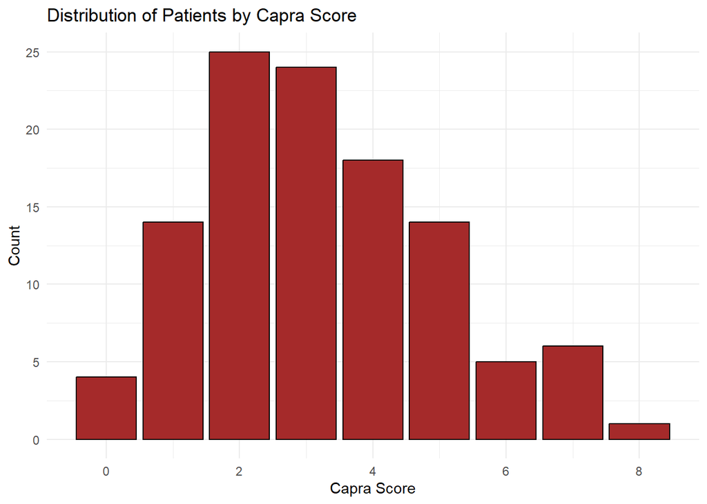

```r
# 5. Distribution of patients with Capra Score
ggplot(Clinical, aes(x = Capra.Score)) +
  geom_bar(fill = "brown", color = "black") +
  labs(title = "Distribution of Patients by Capra Score", x = "Capra Score", y = "Count") +
  theme_minimal()
```

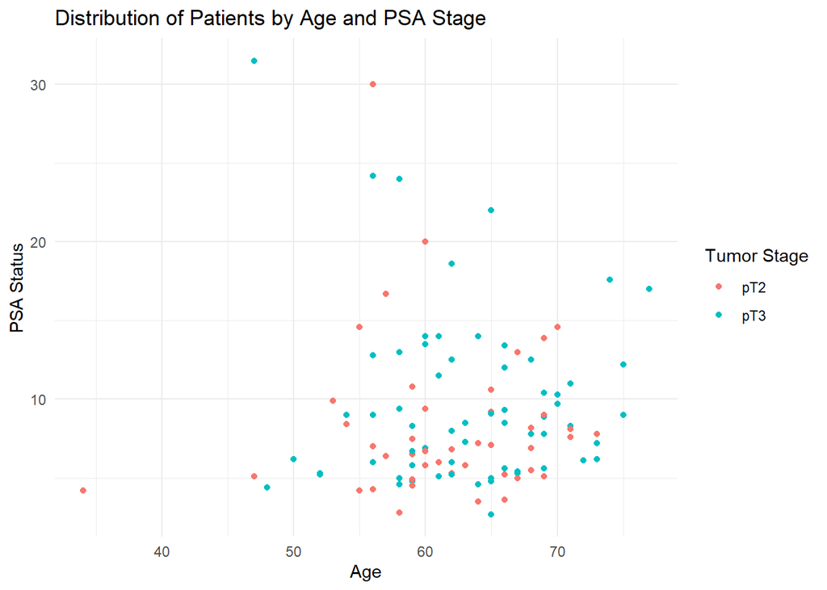

```r
## Age by PSA Status Distribution
ggplot(Clinical, aes(x = Age, y = PSA.Status, color=Tumor.Stage.Binary)) +
  geom_point() +
  labs(title = "Distribution of Patients by Age and PSA Stage",
       x = "Age",
       y = "PSA Status",
       color = 'Tumor Stage') +
  theme_minimal()
```

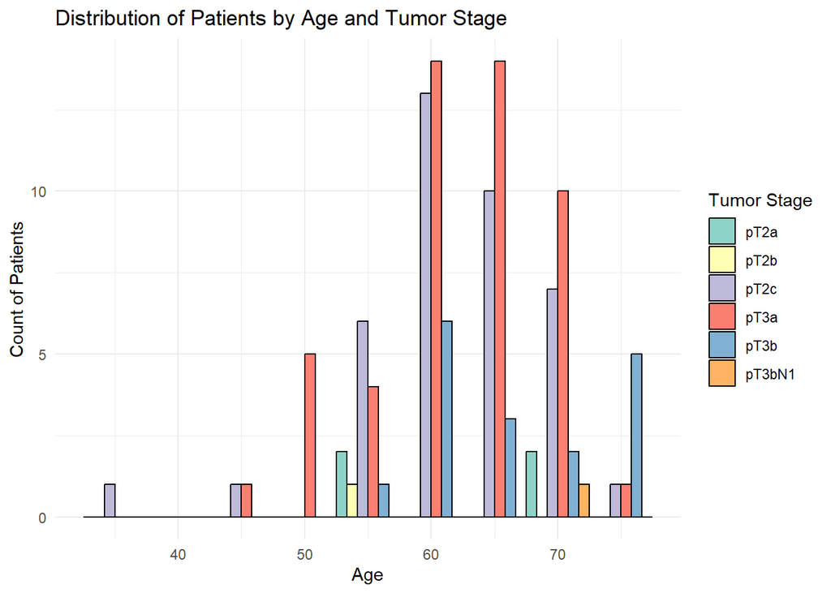

```r
## Age by Tumor Stage Distribution
ggplot(Clinical, aes(x = Age, fill = Tumor.Stage)) +
  geom_histogram(binwidth = 5, position = "dodge", color = "black") +
  labs(title = "Distribution of Patients by Age and Tumor Stage",
       x = "Age",
       y = "Count of Patients") +
  scale_fill_brewer(palette = "Set3", name = "Tumor Stage") +
  theme_minimal()
```

## Composite Score to Define Aggressive Disease

- **Three variables were combined to create a composite score that represented “aggressive disease”**
  - The higher the score, the more aggressive the disease
    - As mentioned in the overview section, aggressive disease ambiguously is defined and inconsistently treated in the real-world setting.
    - The composite score is intended to capture some of the known variables or patient characteristics used to determine presence of aggressive decision
    - In a more in-depth analysis, we would ideally have access to additional genetic markers such as P53, RB, and MYC, would understand 1L treatment for mHSPC, time to disease progression, as well as presence of visceral mets. For the purpose of this analysis it is my hope and expectation that having several of the core components will be sufficient to drive predictive accuracy of disease status.
- **Variables include:**
  - Radical Prostatectomy Gleason Score: The sum of the two most common Gleason patterns in the tumor.
  - Tumor Mutation Burden (TMB): Measurement of the number of mutations in a cancer cell’s DNA.
  - Fraction Genome Altered: Measurement of the percentage of a tumor’s chromosomes that have been altered in copy number.
- **Performed model splitting (80/20)**
  - The split ensures the model(s) are trained on one subset of the data and evaluated on another. Intended to prevent over-fitting.

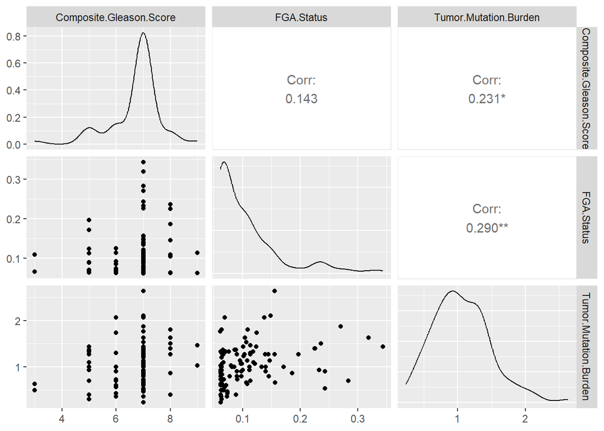

```r
## Load GGally, provide extended functionality for ggplot2,
library("GGally")
## Pairwise plot matrix of the three specified variables
ggpairs(Clinical,columns=c("Composite.Gleason.Score","FGA.Status","Tumor.Mutation.Burden"))
```

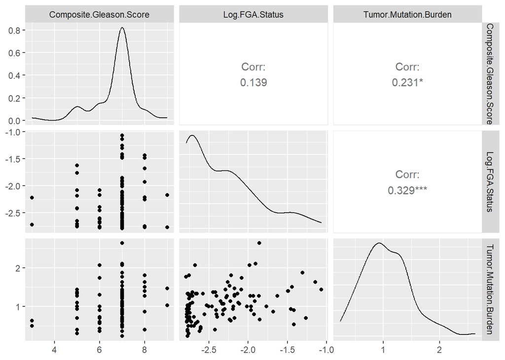

```r
## Composite score with updated FGA to reflect imputed values
ggpairs(Clinical,columns=c("Composite.Gleason.Score","Log.FGA.Status","Tumor.Mutation.Burden"))
```

```r
## Performing splitting to support accuracy of model - 80/20 split
## Obtaining testing dataset on which we can perform predictions and determine prediction accuracy
set.seed(1)
clincal_Filtered=Clinical |> filter(Mutation.Count<100)
train.rows = sort(sample(1:nrow(Clinical), size=round(0.8*nrow(Clinical))))
Clinical_Train=Clinical[train.rows,]
Clinical_Test=Clinical[-train.rows,]
```

## Principal Component Analysis (PCA)

```r
PCA_Results=prcomp(~Composite.Gleason.Score + Log.FGA.Status + Tumor.Mutation.Burden,
       data = Clinical_Train,
       scale.=TRUE)
PCA_Results
```

```
Standard deviations (1, .., p=3):
[1] 1.2372551 0.9229684 0.7857030

Rotation (n x k) = (3 x 3):
                               PC1        PC2         PC3
Composite.Gleason.Score -0.4704143  0.8773317 -0.09486555
Log.FGA.Status          -0.6142289 -0.4027218 -0.67862946
Tumor.Mutation.Burden   -0.6335876 -0.2609678  0.72832862
```

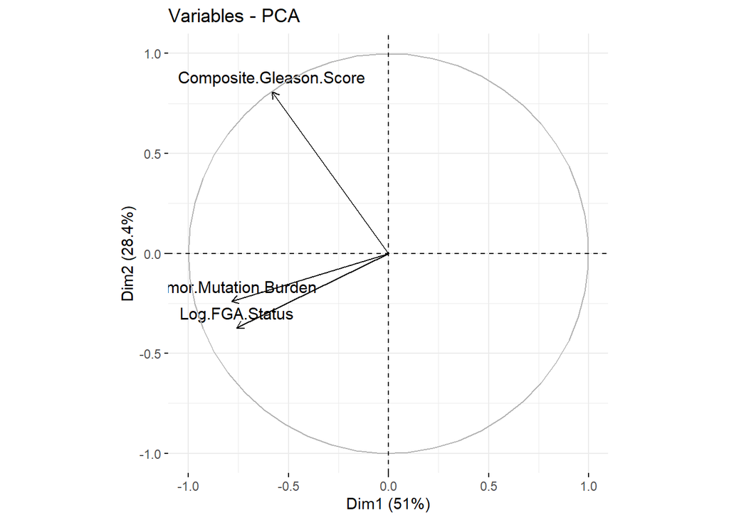

```r
##Shows how PCA relates to different variables
fviz_pca_var(PCA_Results)
```

## Bootstrapping

- Assess stability and variability in PCA score - focus on Clinical_Train (training data)
- Replicate 5000 times

```r
## Bootstrapping
Get_Principal_Component_One=function(data){
bootstrapped_rows=sample(1:nrow(data),replace=TRUE)
  PCA_Results=prcomp(~Composite.Gleason.Score + Log.FGA.Status + Tumor.Mutation.Burden,
       data = data[bootstrapped_rows, ], ## Doing PCA with bootstrapped sample
       scale.=TRUE)
predict(PCA_Results,newdata = data)[,1] * sign(sum(PCA_Results$rotation[,1]))
 }

### Ensure correlation of higher TMB, FGA, Gleason with more aggressive
##If first PCA is going same direction as gleason, nothing will change. If going opposite direction - becomes negative

## Use replicate to apply PCA 1 Function many times to dataset
set.seed(13) ## Can be any #
BootstrappedPCA=replicate(5000,Get_Principal_Component_One(Clinical_Train))
```